# Info

### Definitions (as in Lynott & Connell, 2009, 2013)

- Dominant modality: highest-rated modality;
- Modality exclusivity: range of the three modality ratings divided by the sum;
- Perceptual strength: highest rating across modalities.

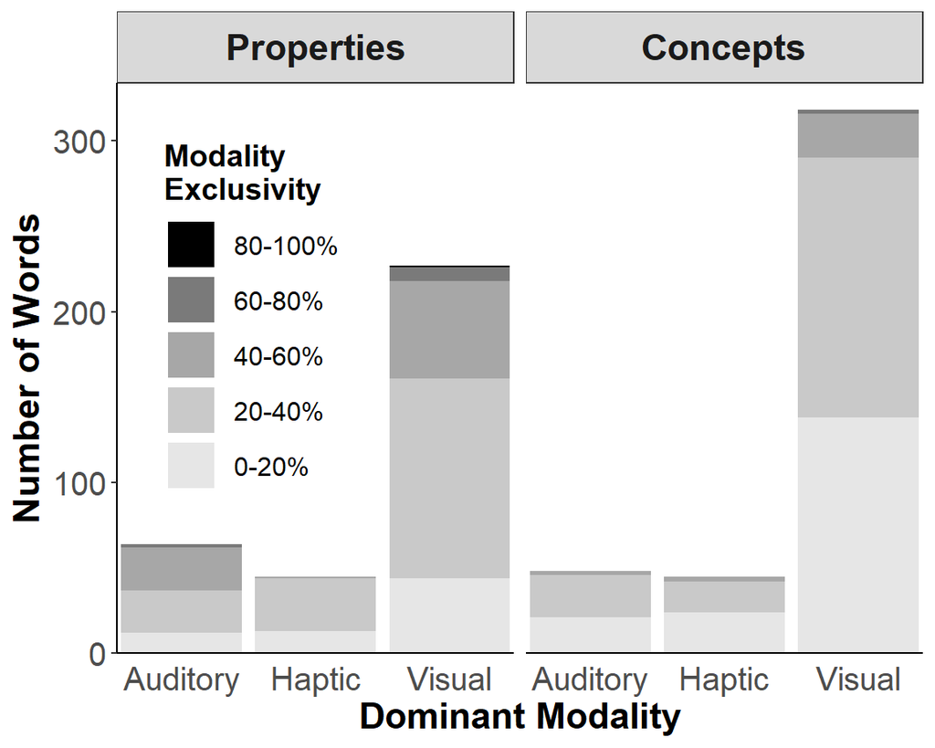

##### Figure 1. Number of words in the norms per word category, dominant modality, and modality exclusivity. [Github](https://raw.githubusercontent.com/pablobernabeu/Modality-exclusivity-norms-747-Dutch-English-replication/master/stacked_exc.png)

These norms were validated in an experiment demonstrating that shifts across trials with different dominant modalities incurred semantic processing costs ([Bernabeu, Willems, & Louwerse, 2017](https://doi.org/10.31234/osf.io/a5pcz)). All data for that study are [available](https://osf.io/97unm/wiki/home/), including a [dashboard](https://pablobernabeu.shinyapps.io/ERP-waveform-visualization_CMS-experiment/).

The **properties** and the **concepts** may also be consulted together on a **table**. Distinct relationships emerged among the modalities, with the visual and haptic modalities being more related to each other than to the auditory modality. This ties in with findings that, in conceptual processing, modalities can be collated based on language statistics (Louwerse & Connell, 2011). Furthermore, properties were found to be more strongly perceptual than concepts (**cf. English norms by Lynott & Connell, 2009, 2013**).

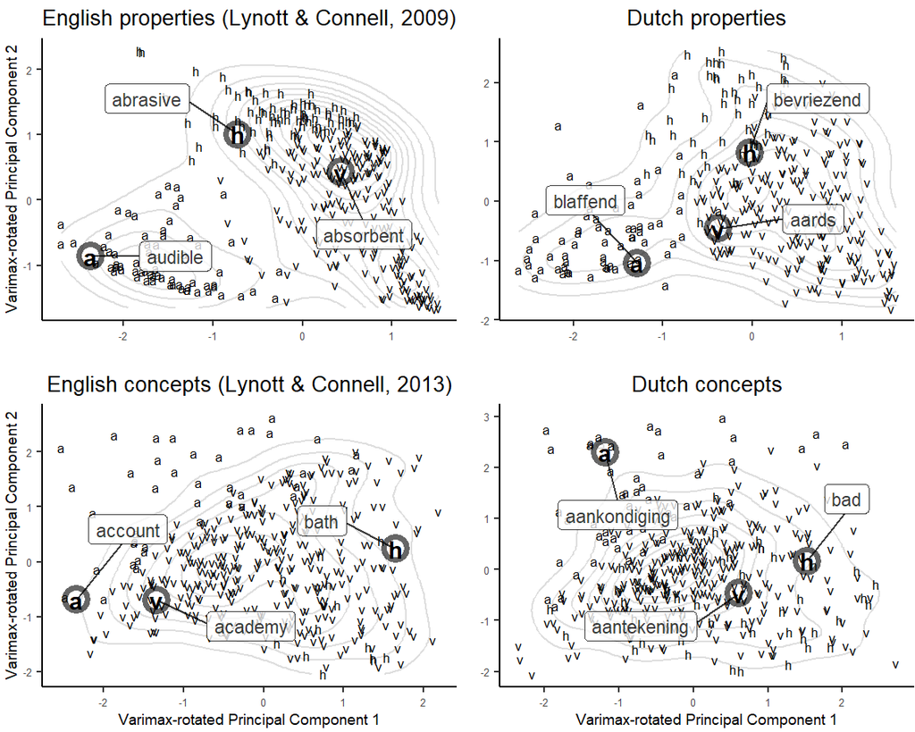